# Omitted Variable Bias

Chris Lavoie

August 9, 2018

## Algebra Introduction

Suppose we have a linear relationship between y, and 4 independent variables, x1, x2, x3 and x4

$$x_1 = \begin{bmatrix} x_{11}\\
x_{12}\\
.\\
.\\
x_{1n}
\end{bmatrix},
x_2 = \begin{bmatrix} x_{21}\\
x_{22}\\
.\\
.\\
x_{2n}
\end{bmatrix},
x_3 = \begin{bmatrix} x_{31}\\
x_{32}\\
.\\
.\\
x_{3n}
\end{bmatrix},
x_4 = \begin{bmatrix} x_{41}\\
x_{42}\\
.\\
.\\
x_{4n}
\end{bmatrix}$$

And we are trying to estimate y.
$$y = \begin{bmatrix}
y_1\\
y_2\\
.\\
.\\
y_n
\end{bmatrix}$$

We know we can estimate this with the equation $'hat{y}=X\hat{\beta} + \hat{u}$.

It would look a little like this:

$$\hat{y} = \begin{bmatrix}
1 & x_{11} & x_{21} & x_{31} & x_{41}\\
1 & x_{21} & x_{22} & x_{32} & x_{42}\\
. & . & . & .\\
1 & x_{n1} & x_{n2} & x_{n3} & x_{n4}
\end{bmatrix}
\begin{bmatrix}
\hat{\beta_0}\\
\hat{\beta_1}\\
\hat{\beta_2}\\
\hat{\beta_3}\\
\hat{\beta_4}\\
\end{bmatrix} +
\begin{bmatrix} \hat{u_1}\\
\hat{u_2}\\
.\\
\hat{u_n}\\
\end{bmatrix}$$

We also know we can get the Beta estimator through the equation $\hat{\beta} = (X'X)^{-1}X'y$

How do we know whether or not a regression estimator is biased? Well let’s do a little experiment!

Suppose the true value of the output $y$ is $y_i = 1 + 3x_1 + 2x_2 + 0x_3 + x_4$, with some additional noise. Suppose also that $x_1, x_2, x_3$ are normally distributed, but $x_4 = 2x_1 + x_2$ with a normally distributed random component.

What happens when we run a linear regression on all our X’s?

```r
x1 <- rnorm(n = 1000, mean=0, sd=1)
x2 <- rnorm(n=1000, mean=2, sd=2)
x3 <- rnorm(n=1000, mean=1, sd=3)
x4 <- 2*x1 + x2 + rnorm(n=1000, mean=0, sd=1)
y <- 3*x1 + 2*x2 + x4 + 1 + rnorm(n=1000, mean=0, sd=1)
X <- data.frame(1,x1, x2, x3, x4)
colnames(X) <- c("x0", "x1", "x2", "x3", "x4")

find_beta_hat <- function(X, y) {
  # Applying the beta hat formula specified above
  X <- as.matrix(X)
  squared_X <- t(X)%*%X
  # Calculates the inverse of squared_X
  term_1 <- solve(squared_X)
  term_2 <- t(X)%*%y
  beta_hat <- term_1 %*% term_2
}

beta_hat <- find_beta_hat(X,y)

beta_hat
```

```
##            [,1]
## x0  1.003998103
## x1  3.065127617
## x2  2.015288169
## x3 -0.005317042
## x4  0.990951569
```

Whoah cool! We get very close to the actual estimates. (Note: The reason why they arne’t exactly on is because of the random noise we added.)

Keep in mind a couple of things 1. We have data for every variable that impacts y 2. Every variable was placed in the regression.

R has a much more comprehensive Linear Regression solver, so let’s use that to check our work.

```r
data = data.frame(y, X)
summary(lm(y ~ x1 + x2 + x3 + x4, data=data))
```

```
##
## Call:
## lm(formula = y ~ x1 + x2 + x3 + x4, data = data)
##
## Residuals:
##     Min      1Q  Median      3Q     Max
## -3.2366 -0.6120 -0.0148  0.6599  3.0692
##
## Coefficients:
##              Estimate Std. Error t value Pr(>|t|)
## (Intercept)  1.003998   0.046124  21.768   <2e-16 ***
## x1           3.065128   0.068122  44.995   <2e-16 ***
## x2           2.015288   0.034617  58.217   <2e-16 ***
## x3          -0.005317   0.010174  -0.523    0.601
## x4           0.990952   0.030424  32.572   <2e-16 ***
## ---
## Signif. codes:  0 '***' 0.001 '**' 0.01 '*' 0.05 '.' 0.1 ' ' 1
##
## Residual standard error: 0.9879 on 995 degrees of freedom
## Multiple R-squared:  0.9838, Adjusted R-squared:  0.9837
## F-statistic: 1.508e+04 on 4 and 995 DF,  p-value: < 2.2e-16
```

We were able to verify our answers, and get significance estimates! As expected, $x_1, x_2$ and $x_4$ are all statistically significant and $x_3$, which is not at all a factor in y, does not pass the significance test.

Obviously at this point, there are no omitted variables. But let’s get technical.

## Omitted Variable Bias

I’ll be following mostly off of [this wikipedia page](https://en.wikipedia.org/wiki/Omitted-variable_bias) for this section Let’s define two conditions 1. The omitted variable is a determinant in y 2. The omitted variable is correlated with one of the explanatory variables

In our case, $x_4$ is a determinant of y (it’s explicitly in the equation for y), and it is also correlated with both $x_1$ and $x_2$.

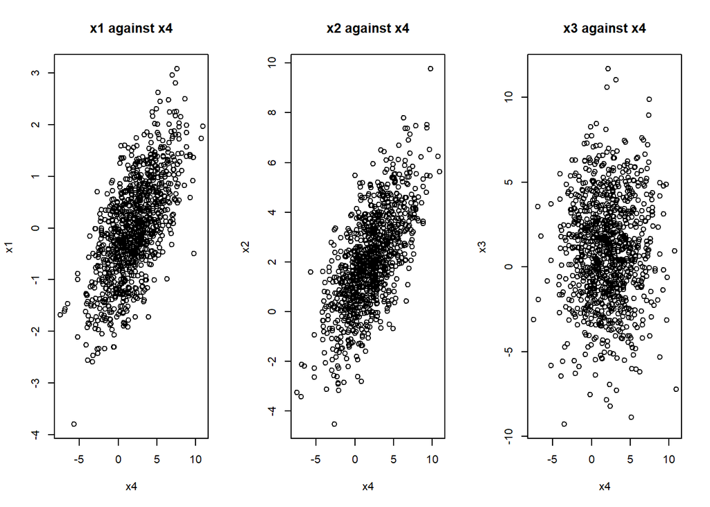

```r
par(mfrow=c(1,3))
plot(x4,x1, main="x1 against x4")
plot(x4,x2, main="x2 against x4")
plot(x4,x3, main="x3 against x4")
```

So what happens when we omit $x_4$ from our regression? (We’ll use the lm() function for this)

```r
summary(lm(y ~ x1 + x2 + x3, data=data))
```

```
##
## Call:
## lm(formula = y ~ x1 + x2 + x3, data = data)
##
## Residuals:
##     Min      1Q  Median      3Q     Max
## -6.0477 -0.9392  0.0189  1.0150  4.0294
##
## Coefficients:
##             Estimate Std. Error t value Pr(>|t|)
## (Intercept)  1.02559    0.06626  15.478   <2e-16 ***
## x1           5.01824    0.04644 108.048   <2e-16 ***
## x2           3.01170    0.02328 129.384   <2e-16 ***
## x3          -0.01481    0.01461  -1.014    0.311
## ---
## Signif. codes:  0 '***' 0.001 '**' 0.01 '*' 0.05 '.' 0.1 ' ' 1
##
## Residual standard error: 1.419 on 996 degrees of freedom
## Multiple R-squared:  0.9665, Adjusted R-squared:  0.9664
## F-statistic:  9571 on 3 and 996 DF,  p-value: < 2.2e-16
```

Both the estimates of $x_1$ and $x_2$ were revised upward! By omitting one of the independent variables that was correlated with the others, we now have inaccurate estimates of $\hat{\beta_1}$ and $\hat{\beta_2}$

## Omitted Variable Bias: The Algebra

First, the statistical term for bias in an estimator. An estimator if biased if $E[\hat{\beta}|X] \neq \beta$.

Let’s rewrite the Linear Equation form as $y_i = x_i\beta + z_i\delta + u_i$ Recall that $\hat{\beta} = (X'X)^{-1}X'y$ If we substitute y for $X\beta + Z\delta + U$

$$\hat{\beta} = (X'X)^{-1}X'(X\beta + Z\delta + U)\\
\hat{\beta} = ((X'X)^{-1}X'X)\beta + (X'X)^{-1}X'Z\delta + (X'X)^{-1}X'U\\
\hat{\beta} = \beta + (X'X)^{-1}X'Z\delta + (X'X)^{-1}X'U$$

If we take the expected value of $\hat{\beta}$ conditional on $X$…
$$E[\hat{\beta}|X] = E[\beta|X] + (X'X)^{-1}E[X'Z|X]\delta + (X'X)^{-1}X'E[U|X]$$
$$E[\hat{\beta}|X] = \beta + (X'X)^{-1}E[X'Z|X]\delta + 0$$
If $\delta=0$ (It is not a predictor of Y), the second term will reduce to zero, and we will have $E[\hat{\beta}|X] = \beta$, which is an unbiased estimator. If Z is uncorrelated with X, it will also reduce to zero!